# 데이터 과학자가 바라본 제7회 지방선거

경기도 기초단체장 - 여론조사

2018-06-03

# 1 경기도 지방선거

경기도 지방선거 기초단체장에 대한 선거결과를 위키백과사전에서 확인이 가능하다.

- [대한민국 제6회 지방 선거: 기초자치단체장](https://ko.wikipedia.org/wiki/대한민국_제6회_지방_선거_기초자치단체장)
- [대한민국 제7회 지방 선거 여론조사](https://namu.wiki/w/제7회%20전국동시지방선거/여론조사)

[대한민국 제7회 지방 선거 여론조사](https://namu.wiki/w/제7회%20전국동시지방선거/여론조사) 결과는 현재 시점 2018-06-03 여론조사결과를 바탕으로 제7회 지방선거 기초단체장 정당별 획득수와 각 지역별 당선자 지지율을 예측해 본다.

# 2 선거 결과 데이터

## 2.1 [대한민국 제6회 지방 선거: 기초자치단체장](https://ko.wikipedia.org/wiki/대한민국_제6회_지방_선거_기초자치단체장)

[대한민국 제6회 지방 선거: 기초자치단체장](https://ko.wikipedia.org/wiki/대한민국_제6회_지방_선거_기초자치단체장) 웹사이트에서 데이터를 긁어와서 데이터프레임으로 변환시킨다.

```r
# 0. 환경설정 -----
library(tidyverse)
library(rvest)
library(glue)

# 1. 제 6 회 지방선거 여론조사 -----

six_gg_url <- "https://ko.wikipedia.org/wiki/대한민국_제6회_지방_선거_기초자치단체장"

# Sys.setlocale("LC_ALL", "C")

six_dat <- read_html(six_gg_url) %>%
    html_nodes('table') %>%
    .[[8]] %>%
    html_table(fill=TRUE)

# Sys.setlocale("LC_ALL", "Korean")

# 2. 데이터 정제 -----

six_df <- six_dat %>%
    mutate(득표수 = str_replace_all(득표수, ",", "") %>% as.integer,
              득표율 = str_replace_all(득표율, "%", "") %>% as.numeric) %>%
    mutate(선수 = ifelse(비고 == "", "초선", 비고)) %>%
    mutate(선수 = factor(선수, levels = c("초선", "재선", "3선"))) %>%
    rename(시군명=지역)

six_df %>% write_rds("data/gg_six_df.rds")
```

## 2.2 [대한민국 제7회 지방 선거 여론조사](https://ko.wikipedia.org/wiki/대한민국_제7회_지방_선거_여론_조사)

현재 시점 2018-06-03 계속해서 지방선거 여론조사 결과가 갱신되기 때문에 현시점에서

[대한민국 제7회 지방 선거 여론조사](https://ko.wikipedia.org/wiki/대한민국_제7회_지방_선거_여론_조사) 경기도 기초단체장 페이지에서 여론조사 결과를 긁어온다.

```r
# 1. 제 7 회 지방선거 여론조사 -----

sigun_list <- vector("list", length=0)
sigun_v <- read_rds("data/sigun_name.rds")

Sys.setlocale("LC_ALL", "C")
base_url <- "https://namu.wiki/w/제7회 전국동시지방선거/여론조사"

for(i in 1:length(sigun_v)) {

## 경기도 기초단체장
    sigun_list[[i]] <- read_html(base_url) %>%
        html_nodes('table') %>%
        .[[15+i]] %>%
        html_table(fill=TRUE)
}

Sys.setlocale("LC_ALL", "Korean")

names(sigun_list) <- sigun_v

listviewer::jsonedit(sigun_list)

# 2. 데이터 정제 -----
gg_sigun_dat <- tibble(
    sigun = sigun_v,
    df = sigun_list
)

## 2.1. 시군별 후보명  -----
gg_hubo_df <- gg_sigun_dat %>%
    unnest(df) %>%
    filter(X1 == "조사 기관")

## 2.2. 여론조사  -----
gg_sigun_df <- gg_sigun_dat %>%
    unnest(df) %>%
    filter(X1 != "조사 기관")

names(gg_sigun_df) <- c("sigun", "조사기관", "조사일", "X1", "X2", "X3", "X4", "X5", "X6", "X7", "X8", "X9", "X10")

gg_sigun_df <- gg_sigun_df %>%
    separate(조사일, into=c("시작일", "종료일"), sep="~") %>%
    mutate(시작일 = str_replace(시작일, "월", "-")) %>%
    mutate(시작일 = str_replace(시작일, "일", "")) %>%
    mutate(시작일 = lubridate::ymd(paste0("2018-",시작일))) %>%
    group_by(sigun) %>%
    arrange(시작일) %>%
    filter(row_number()==n()) %>%
    select(-종료일) %>%
    mutate(조사기관 = str_extract(조사기관, "[가-힣]+")) %>%
    mutate(조사기관 = ifelse(sigun == "가평군", "코리아정보리서치", 조사기관))

gg_sigun_long_df <- gg_sigun_df %>%
    select(-조사기관) %>%
    gather(후보, 지지율, -sigun, -시작일) %>%
    mutate(지지율 = str_replace(지지율, "%", "") %>% as.numeric)

gg_sigun_long_df %>% write_rds("data/gg_sigun_long_df.rds")

## 2.3. 선두후보 선택  -----

gg_sigun_now_df <- gg_sigun_long_df %>%
    group_by(sigun) %>%
    arrange(-지지율) %>%
    filter(row_number() == 1) %>%
    ungroup()

gg_sigun_now_df %>% write_rds("data/gg_sigun_now_df.rds")
```

# 3 경기 제6회 기초단체장

제6회 지방선거는 역사적 사실로 각 정당별 기초단체장 선출데이터에 근거하고, 제7회 지방선거 광역단체장은 2018-06-03 기준 여론조사 기준으로 경기도 지역 기초단체장을 추정한다. 그리고, 정당명칭이 제6회부터 현재까지 지속적으로 변경이 되어 일관성을 위해서 다음과 같이 정당명을 정리한다.

- 제6회 지방선거
  - 새누리당 → 자유한국당
  - 새정치민주연합 → 더불어민주당

## 3.1 기초단체장 당선표

경기도 제6회 지방선거 기초단체장에 대한 데이터 검증작업을 겸해서 표로 나타내 보자.

```r
# 1. 제 6 회 지방선거 -----
six_df <- read_rds("data/gg_six_df.rds") %>%
    select(-7) %>%
    mutate(득표율 = 득표율 /100)

# 2. 탐색적 데이터 분석 -----
## 2.1. 표
six_df %>%
    arrange(-득표수) %>%
    datatable() %>%
    formatPercentage(c("득표율"), digits=1) %>%
    formatCurrency(c("득표수"), currency="", digits=0)
```

|  | 시군명 | 기호 | 후보 | 정당 | 득표수 | 득표율 | 선수 |
| --- | --- | --- | --- | --- | --- | --- | --- |
| 1 | 경기도 수원시 | 2 | 염태영 | 새정치민주연합 | 296875 | 0.594 | 재선 |
| 2 | 경기도 성남시 | 2 | 이재명 | 새정치민주연합 | 239685 | 0.551 | 재선 |
| 3 | 경기도 고양시 | 2 | 최성 | 새정치민주연합 | 218354 | 0.514 | 재선 |
| 4 | 경기도 부천시 | 2 | 김만수 | 새정치민주연합 | 192038 | 0.547 | 재선 |
| 5 | 경기도 용인시 | 1 | 정찬민 | 새누리당 | 188787 | 0.475 | 초선 |
| 6 | 경기도 안양시 | 1 | 이필운 | 새누리당 | 139840 | 0.502 | 초선 |
| 7 | 경기도 남양주시 | 1 | 이석우 | 새누리당 | 117377 | 0.495 | 3선 |
| 8 | 경기도 양주시 | 1 | 현삼식 | 새누리당 | 117377 | 0.522 | 재선 |
| 9 | 경기도 안산시 | 2 | 제종길 | 새정치민주연합 | 101906 | 0.39 | 초선 |
| 10 | 경기도 화성시 | 2 | 채인석 | 새정치민주연합 | 96388 | 0.483 | 재선 |

[output cut: 21 more lines]

## 3.2 기초단체장 당선지도

```r
# 1. 제 6 회 지방선거 -----
## 1.1. 지방선거 데이터 -----
six_df <- read_rds("data/gg_six_df.rds") %>%
    select(-7) %>%
    mutate(득표율 = 득표율 /100) %>%
    separate(시군명, into=c("시도명", "시군명"))

## 1.2. 경기도 시군코드 --------
sido_cd_df <- read_excel("data/jscode/jscode20171218/KIKmix.20171218.xlsx", sheet="KIKmix")
sigungu_cd_df <- sido_cd_df %>%
    mutate(CTPRVN_CD = str_sub(행정동코드, 1,5)) %>%
    group_by(CTPRVN_CD) %>%
    summarise(시도명 = first(시도명),
                 시군구명 = first(시군구명)) %>%
    mutate(시군구명 = ifelse(is.na(시군구명), 시도명, 시군구명))

gg_cd_v <- sigungu_cd_df %>%
    filter(str_detect(시도명, "경기")) %>%
    pull(CTPRVN_CD)

## 1.3. shp 파일 불러오기 --------
sgg_shp <- st_read("data/shapefile_sgg/TL_SCCO_SIG.shp")
```

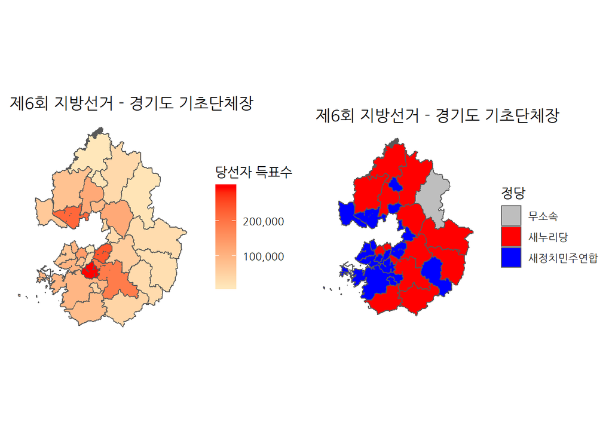

```r
sgg_shp$SIG_KOR_NM <- iconv(sgg_shp$SIG_KOR_NM, from = "CP949", to = "UTF-8", sub = NA, mark = TRUE, toRaw = FALSE)
sgg_smpl_shp <- st_simplify(sgg_shp, dTolerance = 100)

gg_shp <- sgg_smpl_shp %>%
    filter(SIG_CD %in% gg_cd_v)

## 1.4. 경기 시군 데이터 정리 --------
gg_shp <- gg_shp %>%
    mutate(시군명 = case_when(str_detect(SIG_KOR_NM, "수원") ~ "수원시",
                        str_detect(SIG_KOR_NM, "성남") ~ "성남시",
                        str_detect(SIG_KOR_NM, "안양") ~ "안양시",
                        str_detect(SIG_KOR_NM, "안산") ~ "안산시",
                        str_detect(SIG_KOR_NM, "고양") ~ "고양시",
                        str_detect(SIG_KOR_NM, "용인") ~ "용인시",
                        TRUE ~ SIG_KOR_NM))

gg_six_shp <- left_join(gg_shp, six_df, by="시군명")

gg_six_shp <- gg_six_shp %>%
    group_by(시군명) %>%
    summarise(득표수 = first(득표수),
              득표율 = first(득표율),
              정당 = first(정당),
              후보 = first(후보))

# 2. 시각화 --------
## 2.1. 정적 그래프 ----
six_vote_g <- ggplot(data=gg_six_shp, aes(fill=득표수)) +
    geom_sf() +
    theme_minimal(base_family="NanumGothic") +
    labs(title="제6회 지방선거 - 경기도 기초단체장") +
    scale_fill_gradient(low = "wheat1", high = "red", name = "당선자 득표수", labels = scales::comma) +
    theme(panel.grid.major = element_line(colour = 'transparent'),
          panel.grid = element_blank(),
          line = element_blank(),
          axis.ticks = element_blank(),
          axis.text.x = element_blank(),
          axis.text.y = element_blank(),
          legend.position = "right")

## 2.2. 정당 정적 그래프 ----
six_party_g <- ggplot(data=gg_six_shp, aes(fill=정당)) +
    geom_sf() +
    theme_minimal(base_family="NanumGothic") +
    labs(title="제6회 지방선거 - 경기도 기초단체장") +
    scale_fill_manual(values = c("gray", "red", "blue")) +
    theme(panel.grid.major = element_line(colour = 'transparent'),
          panel.grid = element_blank(),
          line = element_blank(),
          axis.ticks = element_blank(),
          axis.text.x = element_blank(),
          axis.text.y = element_blank(),
          legend.position = "right")

grid.arrange(six_vote_g, six_party_g, nrow=1)
```

## 3.3 인터랙티브 기초단체장 당선지도

```r
## 2.3. 인터랙티브 그래프 ----
gg_six_shp %>%
    mutate(득표율 = scales::percent(득표율),
              득표수 = scales::comma(득표수)) %>%
    mapview(., zcol="정당",  col.regions = c("gray", "red", "blue"))
```

[interactive chart not shown]

# 4 제6회 제7회 비교

## 4.1 정당별 경기 기초단체장

그래프 문법(grammar of graphics)이 지원되는 `slopegraph`를 활용하여 각 정당을 대표한 색상을 반영하여 경사그래프로 각 정당별 경기도 기초단체장 선거를 시각화한다.

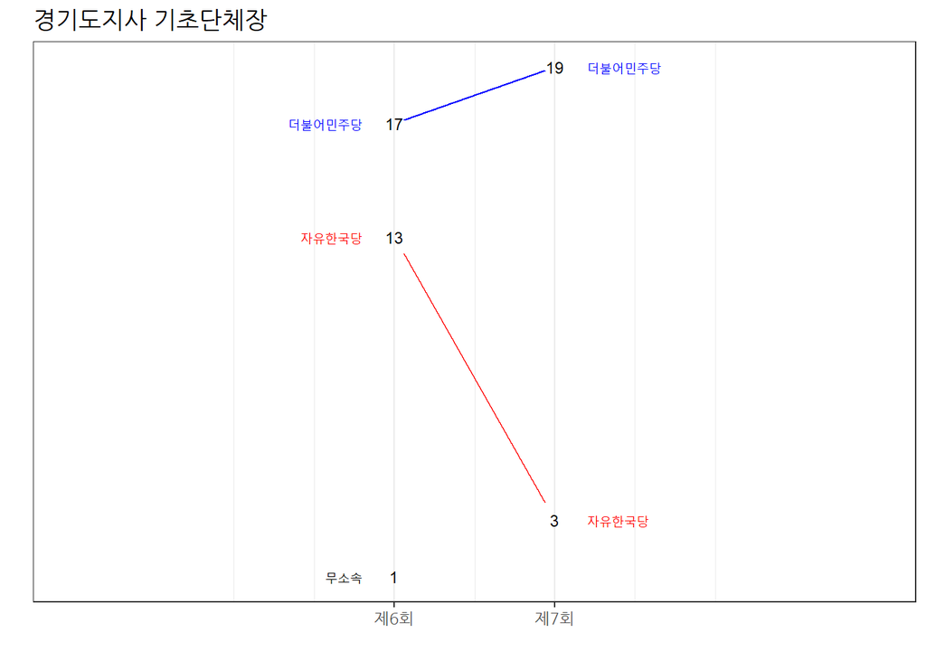

```r
# 1. 데이터 -----
## 1.1. 제6회
gg_six_df <- read_rds("data/gg_six_df.rds") %>%
    as_tibble()  %>%
    separate(시군명, into=c("시도", "시군명"), sep=" ") %>%
    select(시군명, 정당, 득표율)

## 1.2. 제7회 여론조사
gg_seven_df <- read_rds("data/gg_sigun_now_df.rds") %>%
    rename(시군명=sigun,
              득표율=지지율,
              정당=후보) %>%
    select(-시작일)


## 1.3. 데이터 병합 -----
gg_six_viz_df <- gg_six_df %>%
    mutate(정당 = case_when(str_detect(정당, "새누리당") ~ "자유한국당",
                          str_detect(정당, "새정치민주연합") ~ "더불어민주당",
                          TRUE ~ 정당)) %>%
    group_by(정당) %>%
    summarise(제6회 = n())

gg_seven_viz_df <- gg_seven_df %>%
    mutate(정당 = case_when(str_detect(정당, "X2") ~ "자유한국당",
                          str_detect(정당, "X1") ~ "더불어민주당",
                          TRUE ~ 정당)) %>%
    group_by(정당) %>%
    summarise(제7회 = n())


gg_viz_df <- full_join(gg_six_viz_df, gg_seven_viz_df) %>%
    as.data.frame() %>%
    column_to_rownames(var="정당")

# 3. 시각화 -----
## 3.1. 경사그래프 ----
cols <- `[<-`(rep("black", 3), 1, "blue")
cols <- `[<-`(cols, 3, "red")

ggslopegraph(gg_viz_df, offset.x = 0.06, yrev = FALSE,
             col.lines = cols, col.lab = cols,
             main = '경기도지사 기초단체장') +
    theme_bw(base_family="NanumGothic")
```

## 4.2 시군별 경기 기초단체장

그래프 문법(grammar of graphics)이 지원되는 `slopegraph`를 활용하여 각 정당을 대표한 색상을 반영하여 경사그래프로 각 시군별 경기도 기초단체장 지지율을 시각화한다.

나무위키에 여론조사결과가 등록되지 않은 곳을 제외하고, 자유한국당 우세지역(“동두천시”, “가평군”, “여주시”)을 뺀 곳에서 모든 곳에서 민주당이 우세를 이어가고 있다.

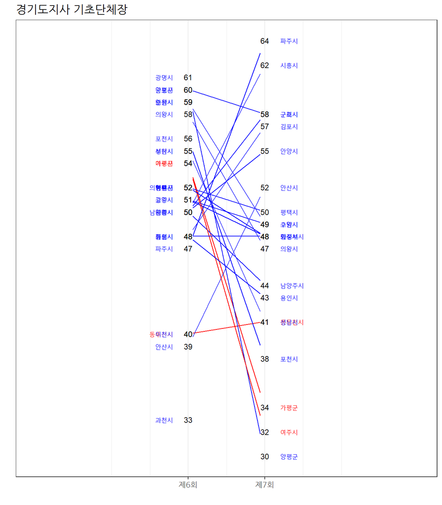

```r
# 1. 데이터 -----
## 1.1. 제6회
gg_six_df <- read_rds("data/gg_six_df.rds") %>%
    as_tibble()  %>%
    separate(시군명, into=c("시도", "시군명"), sep=" ") %>%
    select(시군명, 정당, 득표율)

## 1.2. 제7회 여론조사
gg_seven_df <- read_rds("data/gg_sigun_now_df.rds") %>%
    rename(시군명=sigun,
              득표율=지지율,
              정당=후보) %>%
    select(-시작일)


## 1.3. 데이터 병합 -----
gg_six_viz_df <- gg_six_df %>%
    mutate(정당 = case_when(str_detect(정당, "새누리당") ~ "자유한국당",
                          str_detect(정당, "새정치민주연합") ~ "더불어민주당",
                          TRUE ~ 정당)) %>%
    select(시군명, 제6회 = 득표율)

gg_seven_viz_df <- gg_seven_df %>%
    mutate(정당 = case_when(str_detect(정당, "X2") ~ "자유한국당",
                          str_detect(정당, "X1") ~ "더불어민주당",
                          TRUE ~ 정당)) %>%
    select(시군명, 제7회 = 득표율)


gg_viz_df <- full_join(gg_six_viz_df, gg_seven_viz_df, by="시군명") %>%
    as.data.frame() %>%
    column_to_rownames(var="시군명")

# 3. 시각화 -----
## 3.1. 경사그래프 ----
cls <- rep("black", nrow(gg_viz_df))
cls[rownames(gg_viz_df) %in% c("동두천시", "가평군", "여주시")] <- "red"
cls[!rownames(gg_viz_df) %in% c("동두천시", "가평군", "여주시")] <- "blue"


ggslopegraph(gg_viz_df, offset.x = 0.06, yrev = FALSE,
             col.lines = cls, col.lab = cls,
             main = '경기도지사 기초단체장') +
    theme_bw(base_family="NanumGothic")
```

# 5 경기 제7회 기초단체장

경기도 기초단체장 여론조사결과가 공포된 현재시점 주요 5개 정당기준으로 지지율 `geofacet`으로 시각화한다.

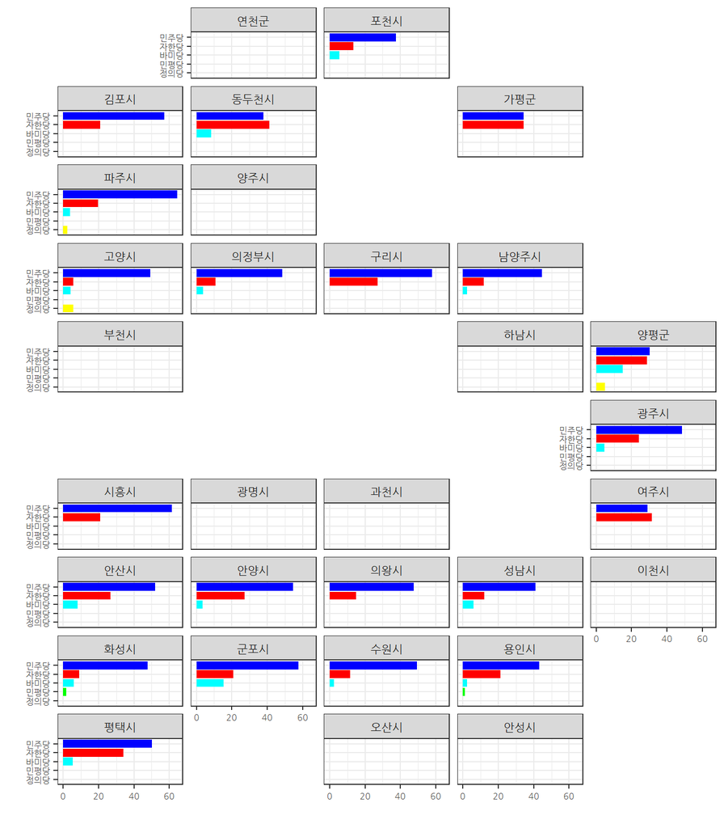

```r
# 1. 데이터 -----
## 1.1. 제7회 여론조사 - 경기도 -----
gg_sigun_long_df  <- read_rds("data/gg_sigun_long_df.rds")

gg_sigun_dat <- gg_sigun_long_df %>%
    mutate(지지율 = ifelse(is.na(지지율), 0, 지지율)) %>%
    filter(!is.na(지지율),
           후보 %in% c("X1", "X2", "X3", "X4", "X5")) %>%
    mutate(후보 = case_when(str_detect(후보, "X1") ~ "민주당",
                            str_detect(후보, "X2") ~ "자한당",
                            str_detect(후보, "X3") ~ "바미당",
                            str_detect(후보, "X4") ~ "민평당",
                            str_detect(후보, "X5") ~ "정의당")) %>%
    select(-시작일) %>%
    spread(후보, 지지율)

gg_sigun_df <- gg_sigun_dat %>%
    gather(정당, 지지율, -sigun) %>%
    rename(name = sigun)

## 1.2. `geofacet` 경기 데이터 -----
map_df <- read_excel("data/선거지도.xlsx", sheet="경기도")

gg_grid_df <- map_df %>%
    gather(sigun, sigunname, -name, convert=TRUE) %>%
    mutate(row = str_extract_all(name, "[0-9]+") %>% unlist,
           col = str_extract_all(sigun, "[0-9]+") %>% unlist)  %>%
    filter(!is.na(sigunname)) %>%
    mutate(name = sigunname) %>%
    select(row, col, code=sigunname, name)


# 3. 시각화 -----
gg_sigun_df %>%
    mutate(정당 = factor(정당, levels=c("민주당", "자한당","바미당","민평당", "정의당"))) %>%
    ggplot(aes(fct_rev(정당), 지지율, fill=정당)) +
    geom_bar(stat="identity") +
    coord_flip() +
    theme_bw(base_family = "NanumGothic") +
    facet_geo(~ name, grid = gg_grid_df) +
    theme(strip.text.x = element_text(size = 8),
          axis.text=element_text(size=6),
          legend.position="none") +
    labs(x="", y="") +
    scale_y_continuous(labels = scales::comma) +
    scale_fill_manual(values= c("blue", "red", "cyan", "green", "yellow"))
```

```r
DT::datatable(gg_sigun_dat)
```

|  | sigun | 민주당 | 민평당 | 바미당 | 자한당 | 정의당 |
| --- | --- | --- | --- | --- | --- | --- |
| 1 | 가평군 | 34.2 | 0 | 0 | 34.3 | 0 |
| 2 | 고양시 | 49.4 | 0 | 4.1 | 5.8 | 5.8 |
| 3 | 광주시 | 48.5 | 0 | 4.7 | 24.1 | 0 |
| 4 | 구리시 | 57.7 | 0 | 0 | 27.2 | 0 |
| 5 | 군포시 | 57.8 | 0 | 15.4 | 20.7 | 0 |
| 6 | 김포시 | 57.2 | 0 | 0 | 20.9 | 0 |
| 7 | 남양주시 | 44.5 | 0 | 2.2 | 11.8 | 0 |
| 8 | 동두천시 | 38 | 0 | 8.4 | 41.3 | 0 |
| 9 | 성남시 | 41.1 | 0 | 5.9 | 12 | 0 |
| 10 | 수원시 | 49.3 | 0 | 2.4 | 11.5 | 0 |

[output cut: 12 more lines]